# Analysis on Chronic Disease Indicators Data using numerous classification and regression techniques

[figure not shown]

[figure not shown]

[figure not shown]

[figure not shown]

[figure not shown]

[figure not shown]

[figure not shown]

[figure not shown]

# Introduction

### Abstract

This project, developed by Theodore Li and Devanshu Khadka, applies six distinct modeling techniques to analyze chronic disease indicators across the United States. The dataset, sourced from the CDC, includes variables such as alcohol use, smoking habits, BMI, and a wide range of chronic diseases (e.g., asthma, diabetes, cancer). The models shown cover both regression and classification methods, including Multiple Regression, Ridge Regression, LOESS fit, k-NN Classification, Naive Bayes Classification, and Logistic Regression. The primary aim is to examine the predictive power of demographic and geographic factors on various health outcomes, focusing on mortality rates and hospitalization likelihood.

Upon trial and error, the supervised learning methods are deemed improper for the data as none of the performance was up to standard despite optimization. However, The unsupervised performance were promising.

Through trial and error, the supervised learning methods, despite extensive optimization, struggled to achieve satisfactory performance on this dataset. However, the unsupervised learning methods, particularly k-NN classification, displayed greater potential in capturing the underlying patterns, offering a more promising approach for the given data characteristics.

### Overview

The area of focus for this project is 6.) Health/Healthcare.

The data was obtained from the CDC: Center for Disease Control and Prevention and includes chronic disease indicators prior to 2024.

This dataset contains 124 indicators, such as alcohol use, smoking habits, BMI, and chronic diseases like Asthma, Diabetes, and Cancer. Each indicator group includes multiple related questions, covering metrics like mortality rates, hospitalization numbers, and emergency department visit rates.

### Data Source

The full dataset can be accessed directly from CDC’s resources. It provides key insights into chronic disease trends across various demographics and locations in the United States.

The raw data has 1.19M entries and 34 columns

[Click here to reach the site to obtain the data](https://data.cdc.gov/Chronic-Disease-Indicators/U-S-Chronic-Disease-Indicators-CDI-2023-Release/g4ie-h725/about_data)  
[Click here to download the data](https://data.cdc.gov/api/views/g4ie-h725/rows.csv?accessType=DOWNLOAD)

### Data Dictionary

YearStart: (Numeric) Starting year of data collection

YearEnd: (Numeric) Ending year of data collection

LocationAbbr: (text) U.S. State Abbreviation

LocationDexc: (text) Location Description

DataSource: (text) Data Source

Topic: (text) topic of study

Question: (text) Question relating to the topic

Response: (text) Response of patient

DataValueUnit: (text) Unit of collected Data Value

DataValueType: (text) What type of data is collected (numerical, character, etc)

DataValue: (text) Data Value

DataValueFootnoteSymbol: (text) data value footnote symbol

LowConfidenceLimit: (Numeric) Lower bound of 95% confidence interval

HighConfidenceLimnit: (Numeric) Upper bound of 95% confidence interval

StratificationCategory1: (text) First category used for grouping

Stratification1: (text) assigned group based on StratificationCategory1

StrateficationCategory2: (text) Second category used for grouping

Stratification2: (text) assigned group based on StrateficationCategory2

### Data Cleaning

Let’s take a look at how many entries pertain to each Topic that we can work with

| Topic | count |
| --- | --- |
| Cancer | 176339 |
| Cardiovascular Disease | 157750 |
| Diabetes | 156808 |
| Chronic Obstructive Pulmonary Disease | 152874 |
| Asthma | 80342 |
| Arthritis | 78300 |
| Nutrition, Physical Activity, and Weight Status | 75418 |
| Overarching Conditions | 73260 |
| Alcohol | 66091 |
| Tobacco | 59396 |
| Older Adults | 26316 |
| Chronic Kidney Disease | 24731 |
| Oral Health | 22273 |
| Mental Health | 13200 |
| Immunization | 9570 |
| Reproductive Health | 9086 |
| Disability | 3922 |

Let’s get rid of redundant columns.

Knowing where we got the data won’t help us make a better prediction as all DataSources are the same so we can drop the DataSource column.

Additionally, there are redundant identification number columnns like LocationID, TopicID, QuestionID, DataValueTypeID that we can drop.

StratificationCategoryID1 is referring to the exact same information as StratificationCategory1, thus we can drop both identification columns for stratification.

Finally, there are the columns that contain NA values like ResponseID, and Stratification3 which we will drop as it won’t contribute anything to the model.

Since we’ll be using this data cleaning process multiple times but for different topics of interest, let’s make a function to remove redundancy in our data cleaning.

```r
#' Function cleans Chronic-Kidney-Disease.csv data and divides it into a smaller datasets for train and test subsets
#'
#' @param relevant_columns a list of columns that we want to keep
#' @param topic The topic that we want to use (i.e. Cancer, Asthma, Tobacco, Alcohol, Cardiovascular Disease, etc)
#' @param question The question we want to answer that is relevant to our topic
#' @param StratificationCategory1 The grouping we want to use to make it consistent in our cleaned dataset
#' @param DataValueType The response variable that we are trying to predict, again to make it consistent in our dataset
#'
#' @return A list contiaining:
#' - cleaned_data: Complete dataset after filtering what we want based on parameters
#' - train_data: Random 70% of the cleaned_data to be used for training
#' - test_data: Random 30% of cleaned_data to be used for testing
#'
clean_data <- function(relevant_columns, topic, question, StratificationCategory1, DataValueType){
  # First, We want to make sure the data we're working with is grouped under the same strata and that we're working with the same data value type
  #Additionally we want to filter the data into the topic, and question of interest, and make sure our Stratification and DataValueType is consistent all based on input parameters.
  cleaned <- data[data$Topic == topic & data$Question == question & data$StratificationCategory1 == StratificationCategory1 & data$DataValueType == DataValueType, ]

  #Next remove redundant columns by only extracting the columns with relevant information
  cleaned <- cleaned[, relevant_columns]

  # Extract X and Y coordinates using gsub

  #Used this post: https://stackoverflow.com/questions/14543627/extracting-numbers-from-   vectors-of-strings
  # to extract the numbers from strings
  #We want to extract the specific X coordinates and Y coordinates into respective numeric columns instead of having them under a single column as a string.
  cleaned$X_coor <- as.numeric(gsub("POINT\\s*\\(([-]?[0-9.]+)\\s[-]?[0-9.]+\\)", "\\1", cleaned$GeoLocation))
cleaned$Y_coor <- as.numeric(gsub("POINT\\s*\\([-]?[0-9.]+\\s([-]?[0-9.]+)\\)", "\\1", cleaned$GeoLocation))

#We can now get rid of the GeoLocation column
cleaned <- subset(cleaned, select = -GeoLocation)

#Turn those categorical columns into numeric columns
cleaned$LocationAbbr <- as.numeric(factor(cleaned$LocationAbbr))
cleaned$Stratification1 <- as.numeric(factor(cleaned$Stratification1))
cleaned$DataValue <-
as.numeric(factor(cleaned$DataValue))

#Split into 70% train 30% test
set.seed(123)
n <- nrow(cleaned)

#Randomly draw 70% of row indexes for training
row_indices <- sample(1:n, size = floor(0.7 * n), replace = FALSE)

train_data <- cleaned[row_indices, ]
test_data <- cleaned[-row_indices, ]

 # Return both complete cleaned data, along with train and test subsets
  return(list(
    cleaned_data = cleaned,
    train_data = train_data,
    test_data = test_data
  ))
}
```

Now our data is ready to be used in a model.

# Multiple regression

### Research Question: What is the average annual number of mortality due to cancer of the colon and rectum?

Colorectal cancer (cancer from colon and rectum) is the third leading cause of cancer related death among men and the fourth leading cause among women [1]. However, in recent years the death rate has been dropping for several decades. This is due to this cancer being highly treatable and often curable if identified at the early stages. Thus, the goal of the section is to accurately identify the average annual number of mortality due to cancer of the colon and rectum to give those individuals a cautious warning if the prediction is high.

### Data Preprocessing

First, we’ll use the clean_data() function initialized in the introduction to get rid of redundant columns and to convert all data values into numeric values which can be properly interpreted by our model.

Next, we’ll look at more specific areas of the data that needs modifications due to the specific research question we are working with. The main area of concern is removing the Year Start and Year End columns.

The reason why we can’t include the Year Start and Year End columns is because in practical use, we’re making real time predictions of the data therefore we can’t have our model exhibit a time dependency as this information will not be available. It’s pointless to make a prediction on the average annual mortality rates of a previous when we know the exact number.

Using the cleaned data, the value we’re predicting is DataValue which represents the annual mortality given other specific parameters. Since this is done in multiple regression I will use the lm() function to fit the linear model which allows for multiple parameters to be included in the model.

```r
cancer_specific_data_list <- clean_data(c(3,11,18,23), "Cancer", "Cancer of the colon and rectum (colorectal), mortality", "Gender", "Average Annual Number")

#Extracting the train, and test splits
cancer_specific_data <- cancer_specific_data_list$cleaned_data
train_data <- cancer_specific_data_list$train_data
test_data <- cancer_specific_data_list$test_data
```

Now our data is ready to be used in a model.

### Initial fitting and summary

```r
multiple_reg_model <- lm(DataValue ~ ., data = cancer_specific_data)
```

| term | estimate | std.error | statistic | p.value |
| --- | --- | --- | --- | --- |
| (Intercept) | 246.7014270 | 45.2655945 | 5.4500870 | 0.0000001 |
| LocationAbbr | -0.3163304 | 0.3612803 | -0.8755817 | 0.3815167 |
| Stratification1 | 22.2500000 | 10.5934752 | 2.1003495 | 0.0360064 |
| X_coor | 1.2302122 | 0.2854268 | 4.3100797 | 0.0000183 |
| Y_coor | 2.9528702 | 0.8604793 | 3.4316576 | 0.0006303 |

We can see that LocationAbbr, has a really high p-value and a really small estimate coefficient. This hints at the variable potentially being redundant and not contributing to our model.

Given that we choose our significance level to be 0.05, all other features have a p-value low enough that we can reject the null hypothesis of the coefficient being 0. Regardless we’ll do further feature analysis to determine what to use.

### AIC for feature extraction

Let us use AIC for feature selection to determine if that really is the case and which features to use.

```
Start:  AIC=8196.48
DataValue ~ LocationAbbr + Stratification1 + X_coor + Y_coor

                  Df Sum of Sq      RSS    AIC
- LocationAbbr     1     17551 18583961 8195.3
<none>                         18566410 8196.5
- Stratification1  1    100993 18667402 8198.9
- Y_coor           1    269597 18836007 8206.2
- X_coor           1    425283 18991692 8213.0

Step:  AIC=8195.25
DataValue ~ Stratification1 + X_coor + Y_coor

                  Df Sum of Sq      RSS    AIC
<none>                         18583961 8195.3
+ LocationAbbr     1     17551 18566410 8196.5
- Stratification1  1    100993 18684953 8197.7
- Y_coor           1    256449 18840410 8204.4
- X_coor           1    408958 18992919 8211.0
```

```
Call:
lm(formula = DataValue ~ Stratification1 + X_coor + Y_coor, data = cancer_specific_data)

Residuals:
    Min      1Q  Median      3Q     Max
-320.68 -122.39   15.21  124.81  397.41

Coefficients:
                Estimate Std. Error t value Pr(>|t|)
(Intercept)     238.7714    44.3439   5.385 9.52e-08 ***
Stratification1  22.2500    10.5920   2.101 0.035979 *
X_coor            1.1927     0.2822   4.227 2.64e-05 ***
Y_coor            2.8561     0.8532   3.347 0.000853 ***
---
Signif. codes:  0 '***' 0.001 '**' 0.01 '*' 0.05 '.' 0.1 ' ' 1

Residual standard error: 151.3 on 812 degrees of freedom
  (16 observations deleted due to missingness)
Multiple R-squared:  0.03703,   Adjusted R-squared:  0.03347
F-statistic: 10.41 on 3 and 812 DF,  p-value: 1.003e-06
```

Our initial model had LocationAbbr, Stratification1, X_coor, and Y_coor with AIC of 8196.48. By using AIC we evaluate our model based on starting off including all features (LocationAbbr, Stratification1, X_coor, Y_coor) then removing each parameter one at a time we are able to gauge the parameter that causes the greatest decrease in AIC, determining the unnecessary parameter.

The only feature that lowers the AIC when removed was LocationAbbr. This indicates that LocationAbbr added unnecessary complexity to the model without increasing the model’s fit. Thus, we can see LocationAbbr was removed therefore this leaves us with parameters Stratification1, X_coor, and Y_coor.

### Analysis of AIC

Using the feature reduced model, let’s attempt another linear regression fit with these features. This final model uses the features: Stratification1 (the gender), X_coor, Y_coor Additionally, we’ll visualize our model. Let’s look at our fit using the X coordinate to the Data Value.

### Plot of of Data Value vs X Coordinate

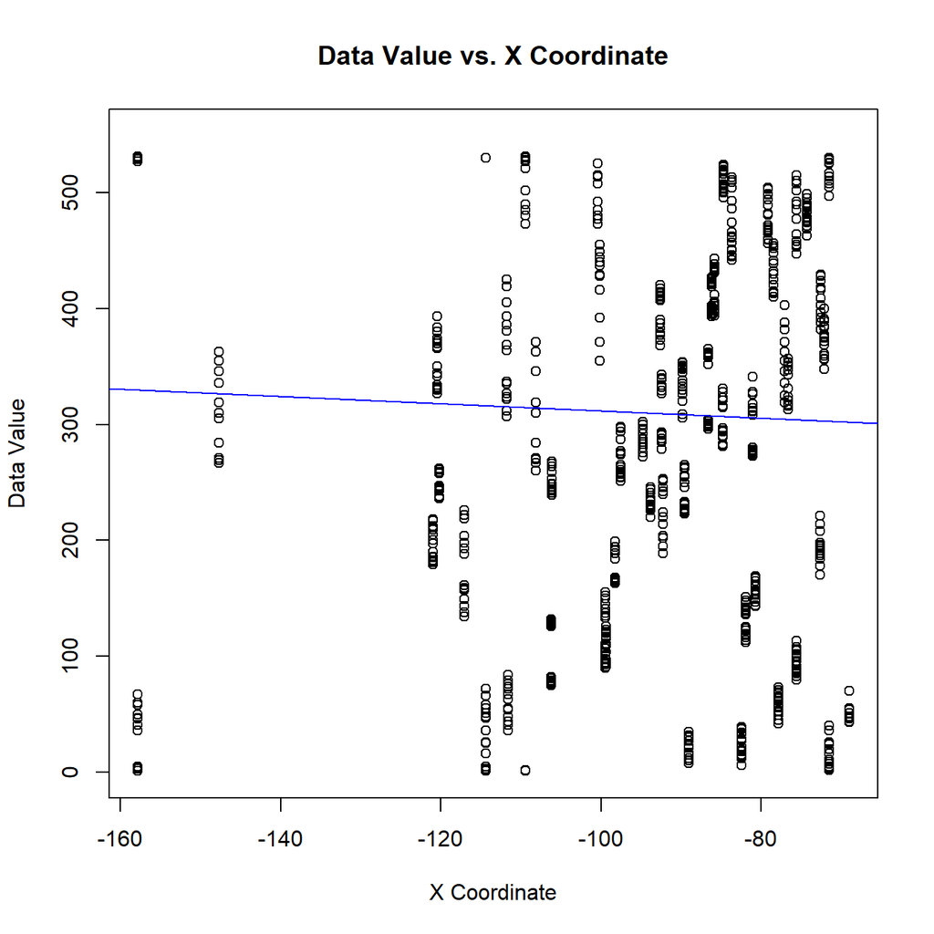

### Plot of of Data Value vs Y Coordinate

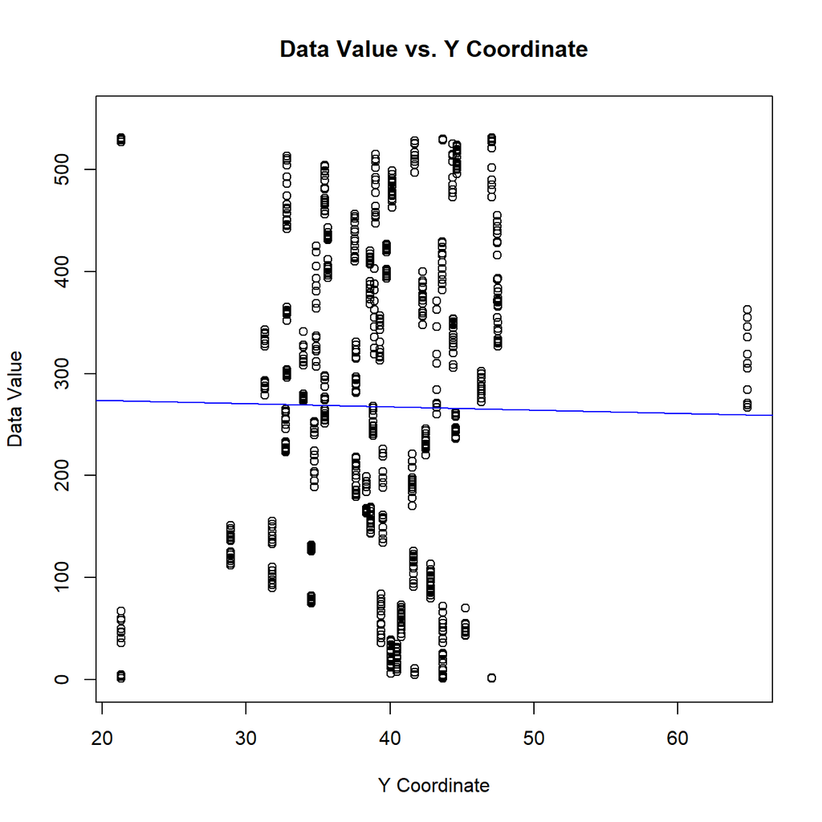

### Results

We can see, it’s hardly a linear fit between X Coordinate and the Data Value, thus our least squares regression line appears practically horizontal.

As expected, if the X Coordinate didn’t share a linear relationship with mortality rates then it’s unlikely that Y Coordinates will exhibit a relationship either.

### Analysis of residuals

Let’s take a deeper analysis of the residuals to determine whether or not a linear relationship is. A residual plot gives us a quick visual assessment on how well the model fits the data. If the data doesn’t violate any assumptions about simple linear regression then there shouldn’t be any trends or patterns in the scatterplot.

### Residual Plot

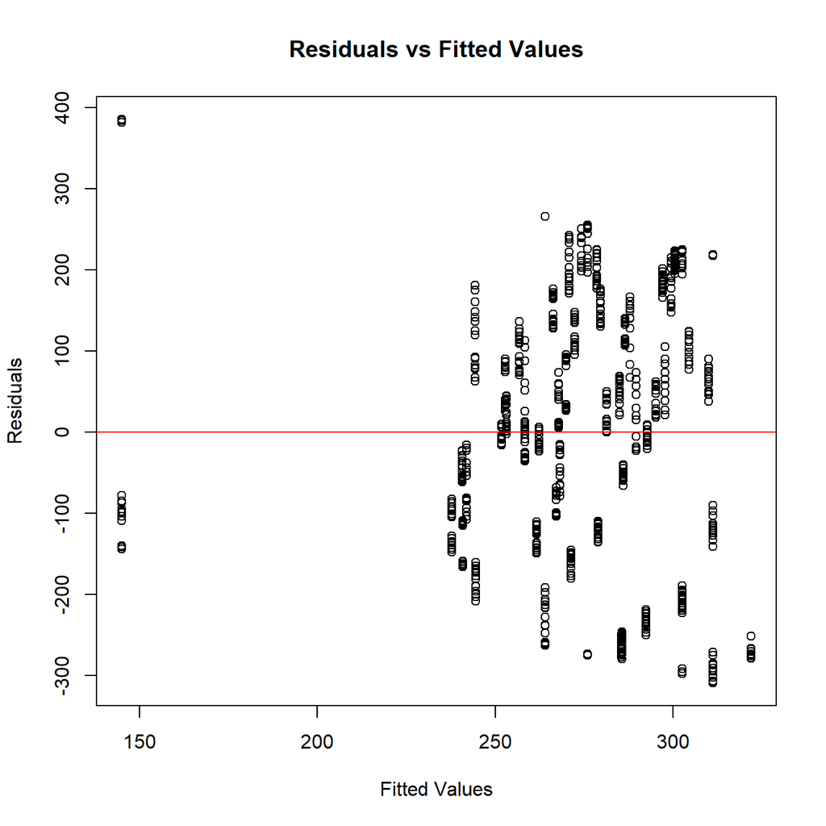

### Result

Looking at the plot we can see a clear clustering of data points toward the right side. This indicates a unevenness in the distribution of the prediction variable, mortality rates due to cancer of rectum and colon. The cluster of the residuals indicates that it is possible that the observations are not independent of one another. In our case, since we are using X and Y coordinates as features, observations close to the same coordinates may experience more similar predictions. This violates the assumption of independent observations for a simple linear regression.

### QQ Plot

Let’s look at a QQ plot of the residuals to assess the normality of the residuals

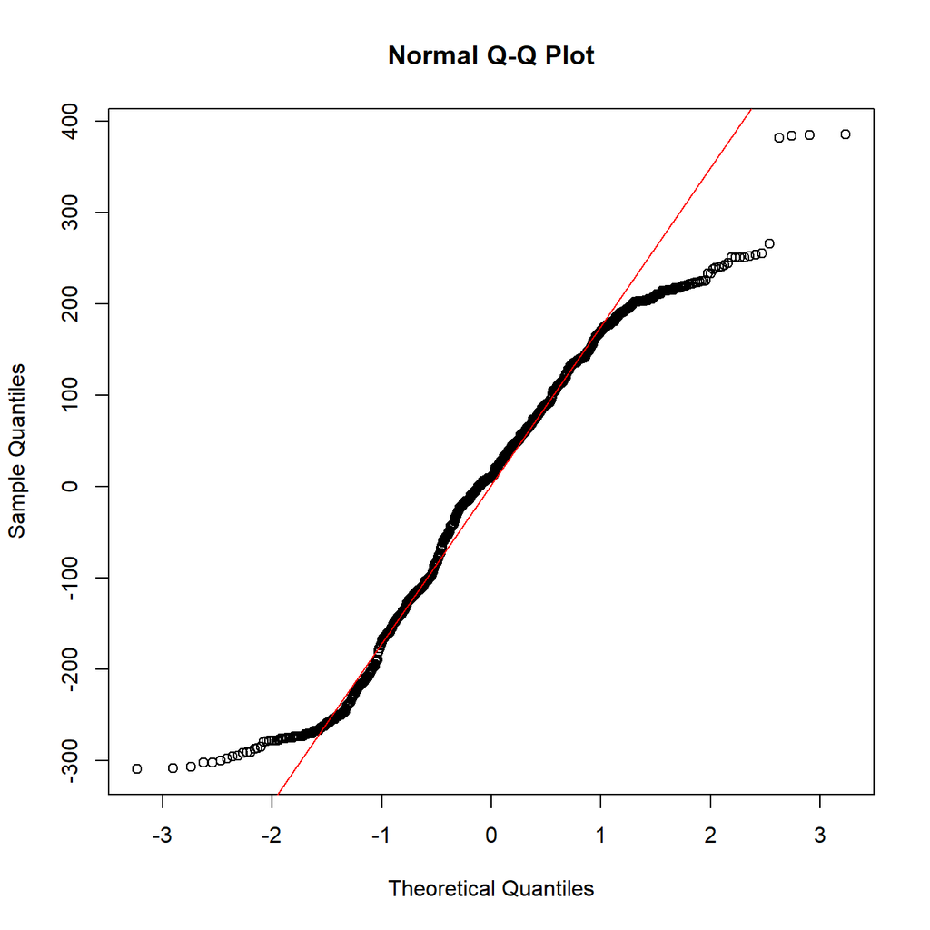

### Results

This breaks the assumption of normality and suggests that the linear model is not able to fully represent the relationship between the predictors and Data Value.

Therefore a linear fit is not ideal for our scenario.

### Model Evaluation

We’ve concluded that our multiple linear model provides a poor fit due to the lack of linear relationship between the predictors and the Data Value.

[output not shown]

Summary of Multiple Regression Model

| Term | Estimate | Std. Error | t-value | p-value |
| --- | --- | --- | --- | --- |
| (Intercept) | 246.701 | 45.266 | 5.450 | 0.000 |
| LocationAbbr | -0.316 | 0.361 | -0.876 | 0.382 |
| Stratification1 | 22.250 | 10.593 | 2.100 | 0.036 |
| X_coor | 1.230 | 0.285 | 4.310 | 0.000 |
| Y_coor | 2.953 | 0.860 | 3.432 | 0.001 |

The model’s poor performance even after using AIC for feature extraction is likely due to the non linear relationship exhibited between the predictors we have chosen and the Data Value. To obtain better performance we would need to make a transformation of the data to introduce a nonlinear component to get better predictions or consider the use of a nonlinear model.

# Ridge Regression fit

### Research Question: How many cases, out of 100,000, for Chronic liver disease mortality is caused by alcohol consumption?

Alcohol-related liver disease causes liver damage due to excessive drinking and is most common in people between 40 and 50. This is due to this occurrence appearing most prominently after years of drinking. The risk factors that are associated with alcohol related liver diseases is age, sex, obesity, amount of alcohol consumption, and genetics [2].

Therefore, by identifying information on individuals, we are going to give a estimate on the mortality cases, out of 100,000, of chronic disease mortality due to alcohol consumption. If the prediction is high, this will provide those who fit the category more caution on their drinking habits.

### Preprocessing

We will use the clean_data function to extract the necessary information from the dataset.

We will use Age-Adjusted Rate as the Data Value Type for predicting Chronic liver disease mortality as it is a lot more likely for older individuals to experience compared to younger people. Thus if we were to use the raw data then it’s likely that we’ll overestimate the mortality rates in older populations and under estimate the younger population due to the uneven distribution of the data.

This adjustment allows for the mortality rates to be compared as though the population had the same age distribution, giving us a more clear result.

```r
alcohol_data_list <- clean_data(c(3,11,18,23), "Alcohol", "Chronic liver disease mortality", "Gender", "Age-adjusted Rate")


alcohol_specific_data <- alcohol_data_list$cleaned_data
train_data <- alcohol_data_list$train_data
test_data <- alcohol_data_list$test_data
```

### Initial Ridge Regression model fitting

We will begin the ridge regression process using the `glmnet` package. This package allows us to choose between Ridge and Lasso regularization.

- Lasso adds a penalty proportional to the absolute value of coefficients, which can effectively remove certain features by setting coefficients to zero.
- Ridge adds a penalty proportional to the square of the coefficients, shrinking them towards zero but not entirely removing them therefore all features will provide some level of contribution to our model.

For our model, we’ll use Ridge Regression, ensuring every predictor has an effect on the fitted values.

```r
library(glmnet)

#All columns except column 3 are predictors
x_train <- as.matrix(train_data[, -3])
#Column 3 is the value we're truing to predict
y_train <- as.matrix(train_data[, 3])

#Get the feature columns from the testing dataset
x_test <- as.matrix(test_data[, -3])

#Get the label columns from the testing dataset
y_test <- as.matrix(test_data[, 3])



#Initial fit with the ridge regression across a range of lambda values
ridge_model <- glmnet(x_train, y_train, alpha = 0)
```

### Determining Tuning Parameter

We need to determine the best tuning parameter to find the proper coefficients for each predictor. To do this we will use Cross-validation: This splits the data into different pieces and trains on selected pieces while tests on the remaining unseen pieces. This is repeated multiple times where each piece is used as the testing piece once.

I will be using cv.glmnet() which performs k-fold cross validation with k=10 folds by default. Thus, we will iterate through the data 10 times with each iteration using all values of .

In the end we select the value for that corresponds to the lowest average error.

Another method for determining the value for is to use lambda.1se which selects the largest value for within 1 standard error from the minimum value. This results in a that has less variance and a bigger value thus giving the coefficients less significance resulting in a potentially more simpler model. This is the method when striving for the bias-variance tradeoff where you are looking for minimal bias and variance at the same time to create a more regularized model.

### CV to find tuning parameter

```r
cv_ridge_model <- cv.glmnet(x_train, y_train, alpha = 0)
# Get the best lambda value based on cross-validation
best_lambda <- cv_ridge_model$lambda.min
print(paste("The value of our tuning parameter is:", best_lambda))
```

```
[1] "The value of our tuning parameter is: 0.0302791605004299"
```

Now we’ve determined our best tuning parameter but let’s visualize the effect of on the MSE by plotting our cross validation model.

### CV Plot

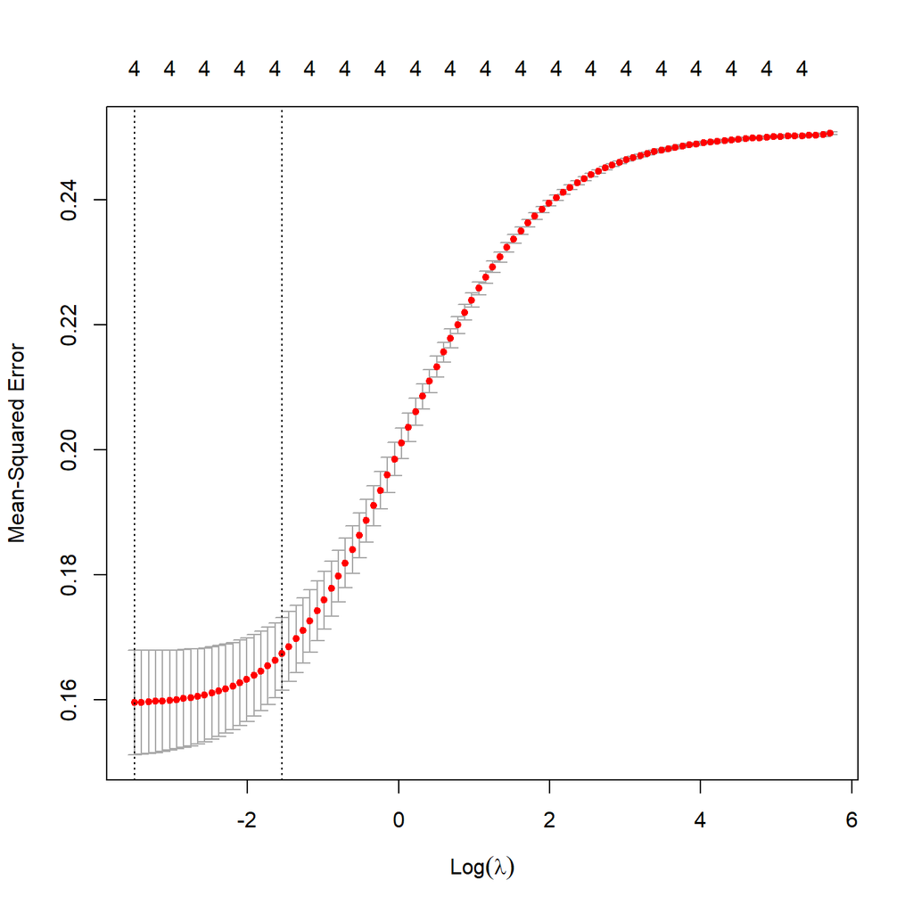

### Results

Looking at this plot we see the mean squared error as we go through the Log throughout all values of . Notably, we observe a S shaped curve meaning that the smaller values of results in lower mean-squared error across all folds of the dataset. However with a smaller MSE also means greater variance as we see through the vertical lines. As the value of increases so does the MSE but variance decreases drastically.

### Table of finalized model

Coefficients of Ridge Regression Model

| Feature | OLS_Coefficient | Ridge_Coefficient | Shrinkage_Effect |
| --- | --- | --- | --- |
| (Intercept) | 2.163 | 2.141 | 0.022 |
| LocationAbbr | 0.002 | -0.001 | 0.003 |
| DataValue | -0.005 | -0.005 | 0.000 |
| X_coor | 0.000 | 0.000 | 0.000 |
| Y_coor | -0.006 | -0.003 | -0.003 |

### Evaluation

Now that we’ve determined the value of the to use as the tuning parameter and refit our model, let’s analyze the new performance metrics.

```
Avg Residuals: 0.2951503
```

```
Mean Absolute Percentage Error: 22.13601 %
```

```
Mean Squared Error (MSE): 0.1415972
```

```
Root Mean Squared Error (RMSE): 0.376294
```

```
R-squared: 0.4333667
```

Let’s further analyze this difference with mean absolute percentage error: where I took the average_residuals divided by the absolute value of the true data values and multiplied by 100 to get the result in percentage form. The result was 22.13601% meaning that our predictions are off by 22.13601% of the true data value.

This is way too high for our model to be practical in making predictions. In a ideal scenario where our predictions would match the true values would give us a absolute percentage error of 0.

# LOESS fit

### Research Question What is the mortality rate due to heart failure?

Heart failure mortality rates vary depending on the age, sex, and lifestyle habits of the individual. A study found that the mortality rate for heart failure has been increasing within the past decade and that the greatest increase were among men aged 45-65 [3].

To combat this, hopefully this model would give a accurate prediction of the mortality rate for people to be more cautious about their lifestyle and dietary habits.

### Preprocessing

Next we will perform a LOESS fit to attempt a nonlinear model fitting technique. We’ve already determined in the Multiple Regression section that a linear fit is not appropriate. Now, rather than using least regression line for predictions we’ll attempt at using a smooth curve that can perhaps capture more information in the data set as we seek the proper balance between variance-bias.

First we must prepare the data by splitting into the 70/30 split for training and testing to get a accurate representation of real world performance on our model. Keeping in mind that LOESS models performs best with lower dimensional data, we want to limit the features used to the ones that are necessary to the model.

```r
alcohol_data_list <- clean_data(c(3,11,18,23), "Cardiovascular Disease", "Mortality from heart failure", "Gender", "Number")


alcohol_specific_data <- alcohol_data_list$cleaned_data
train_data <- alcohol_data_list$train_data
test_data <- alcohol_data_list$test_data
```

### Model Fitting and optimization

We will use a sequence of spans from .25 to 1 iterating by .05 each time to determine the best loess model based on bias-variance trade off. We will build the model based on the train_data but assess the performance using MSE based off the test_data.

```r
test_MSE_values <- numeric()


# Assuming train_data is your dataset with 'DataValue' as the response variable
for (i in seq(0.25, 1, by = 0.05)) {
  # Fit LOESS model with different span values
  output <- loess(DataValue ~ ., data = train_data, degree = 1, span = i)

  test_predictions <- predict(output, newdata = test_data)

  MSE_test <- mean((test_predictions - test_data$DataValue)^2)
  test_MSE_values <- c(test_MSE_values, MSE_test)

}

# Find the best model based on the lowest test MSE
best_span_index <- which.min(test_MSE_values)
best_span <- seq(0.25, 1, by = 0.05)[best_span_index]
cat("The best model is with span =", best_span, "which gives the lowest test MSE of: ", min(test_MSE_values),"\n")
```

```
The best model is with span = 0.3 which gives the lowest test MSE of:  64947.45
```

Now let’s attempt this same process with degree = 2

```r
test_MSE_values <- numeric()


# Assuming train_data is your dataset with 'DataValue' as the response variable
for (i in seq(0.5, 1.5, by = 0.05)) {
  # Fit LOESS model with different span values
  output <- loess(DataValue ~ ., data = train_data, degree = 2, span = i)

  test_predictions <- predict(output, newdata = test_data)

  MSE_test <- mean((test_predictions - test_data$DataValue)^2)
  test_MSE_values <- c(test_MSE_values, MSE_test)

}

# Find the best model based on the lowest test MSE
best_span_index <- which.min(test_MSE_values)
best_span <- seq(0.5, 1.5, by = 0.05)[best_span_index]
cat("The best model is with span =", best_span, "which gives the lowest test MSE of: ", min(test_MSE_values),"\n")
```

```
The best model is with span = 0.95 which gives the lowest test MSE of:  63519.73
```

So the loess model using degree of 2 is able to achieve a smaller MSE on the test_data although the difference is small.

### Plot Degree 1 Span 0.3

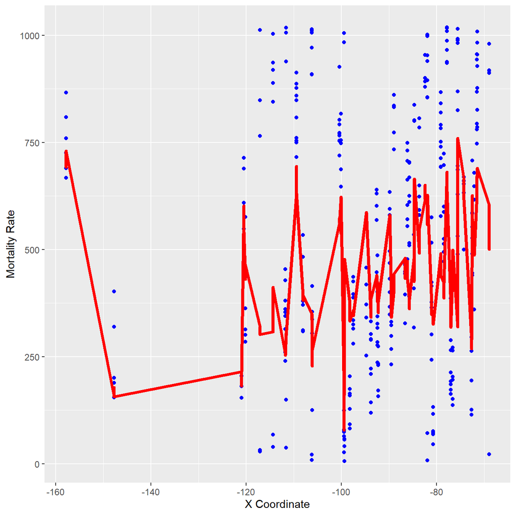

### Plot Degree 2 Span 0.95

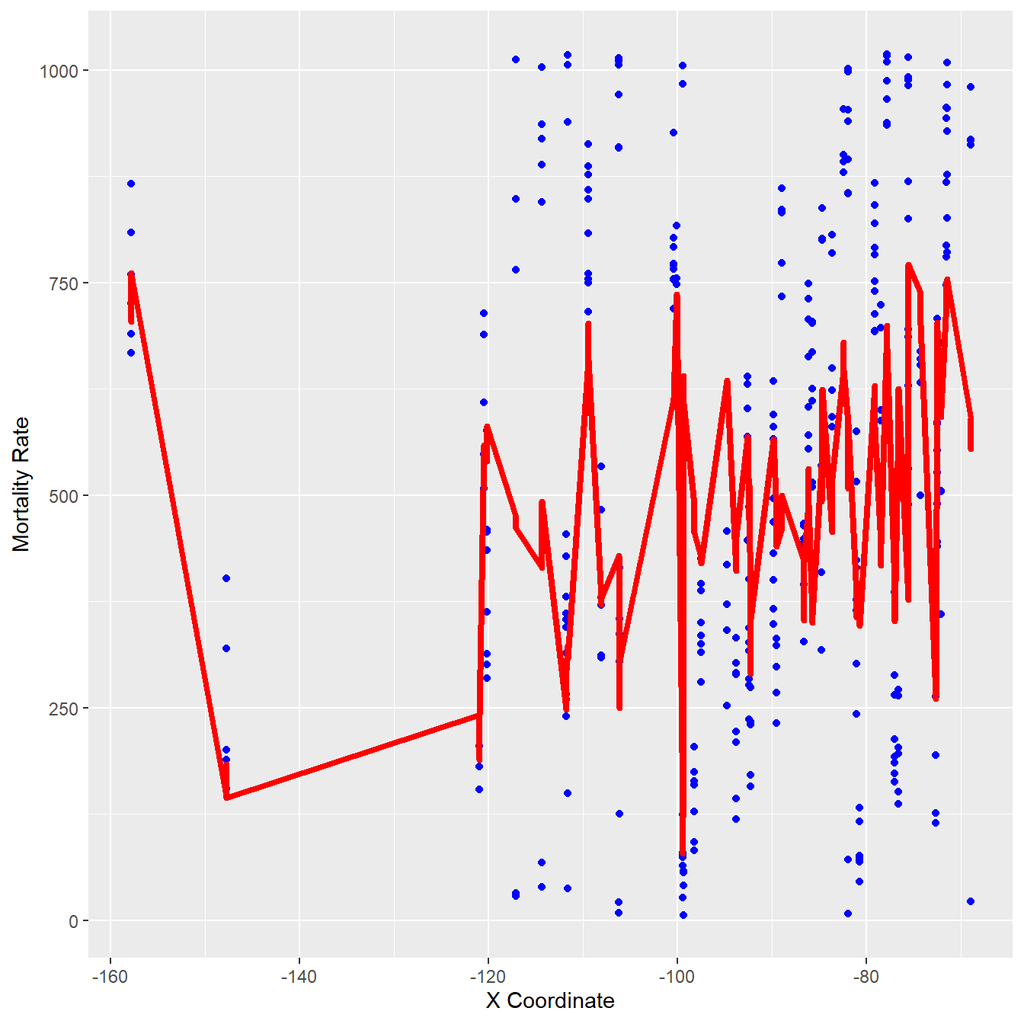

### Evaluation

Our final model with the best performance uses the following features to predict Data Value (Mortality Rate): LocationAbbr (State Abbreviation), Stratification1 (Gender), X_coor, Y_coor

### Results

Summary Table for LOESS

[output not shown]

Based on model selection we chose the loess model which gives us the lowest MSE: 63519.73

Additionally our loess model only explains 25.5% of the total variance in the data.

### Analysis

The model is performing poorly despite optimizing the span and degree of the model. It is likely due to the nature of the data containing many outliers both among the X_coordinates and Y_coordinates which can be seen in the 2 plots under Multiple Regression. Thus, it is difficult for a LOESS model to make accurate predictions. Even by doing a visual inspection of the LOESS plots from degree 1 and 2, we can see that the least regression line does not fit to the data well despite tuning the value for span and degree to achieve the best results. Looking at the plots it seems that the polynomial degree is not enough to properly gauge the best predictions. We conclude that using a line or a curve does not give accurate predictions for the model. The next step would be to use a unsupervised learning method on this dataset, where we gauge the prediction based on proximity of nearby data points rather than constructing a line or a curve.

# K-Nearest Neighbors Classification

### Research question

Our goal is to classify the likelihood of hospitalization for asthma as either ‘High’ or ‘Low’ based on demographic and geographic data. This model can help identifying demographic and geographic trends in asthma hospitalizations. We are going to use gender and location data for this. ### Data Preprocessing

First we filter the dataset to focus on hospitalizations due to asthma. Since our outcome variable will be based on hospitalization rates, we need to ensure the `DataValue` column is formatted correctly. Therefore, we first convert `DataValue` from text to numeric format for analysis.

Next, we make a binary variable called `Hospitalization_Likelihood`for classification. This variable classifies each entry as either “High” or “Low” based on whether the hospitalization rate is above or below the median value. Specifically, data points with `DataValue` greater than or equal to the median are labeled “High,” while those below the median are labeled “Low.”

After creating the target variable, we convert the categorical predictors into a format that can be processed by the k-NN algorithm. Both `LocationAbbr`(state) and `Stratification1`(gender) are converted into numeric factors. This allows the k-NN algorithm to interpret the categorical variables.

Finally, we divide the data into training and testing sets. By setting aside 70% of the data for training and the remaining 30% for testing, we can train the k-NN model and then assess the performance.

### Selecting the optimal k value

Now that the data is prepared, the next step is to determine the optimal value of k which is the number of neighbors in the classification process. We iterate over a range of values for k, from 1 to 15, to identify which value yields the highest accuracy. For each value of k, we apply the k-NN model to the test data and get the resulting accuracy. This helps us get the k value with the heighest accuracy.

```r
# multiple k values
k_values <- 1:15
accuracy_results <- sapply(k_values, function(k) {
  predicted <- knn(train = train_predictors, test = test_predictors, cl = train_target, k = k)
  mean(predicted == test_target)
})
```

### k value accuracy graph

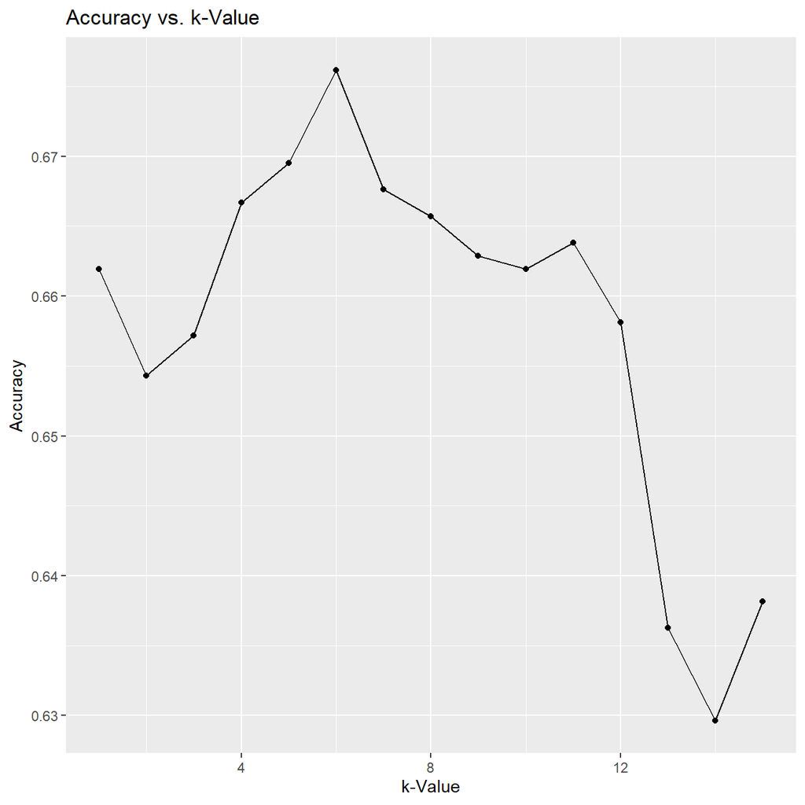

### Model evaluation

Using the optimal k value identified, we now train the final k-NN model and evaluate its performance on the test set. To evaluate the confusion matrix, which shows the number of correct and incorrect classifications for each category is outputted. Additionally, the confusion matrix allows us to calculate key performance metrics such as accuracy, sensitivity, and specificity.

The overall accuracy indicates the proportion of correct predictions made by the model, while sensitivity shows how well the model identifies cases labeled as “High.” Specificity reveals the model’s ability to correctly identify cases labeled as “Low.” By getting these values, we can judge the strengths and weaknesses of the model.

```
Confusion Matrix and Statistics

          Reference
Prediction High Low
      High  291 128
      Low   223 411

               Accuracy : 0.6667
                 95% CI : (0.6373, 0.6951)
    No Information Rate : 0.5119
    P-Value [Acc > NIR] : < 2.2e-16

                  Kappa : 0.3301

 Mcnemar's Test P-Value : 5.239e-07

            Sensitivity : 0.5661
            Specificity : 0.7625
         Pos Pred Value : 0.6945
         Neg Pred Value : 0.6483
             Prevalence : 0.4881
         Detection Rate : 0.2764
   Detection Prevalence : 0.3979
      Balanced Accuracy : 0.6643

       'Positive' Class : High
```

```
Accuracy with k = 6 : 0.6666667
```

### Results and Analysis

The analysis shows that the optimal value of k for this model is 6, which achieved the highest accuracy during testing. The final model’s confusion matrix shows that it correctly classifies approximately 66.67% of cases. This accuracy suggests moderate predictive capability, with the model performing well at distinguishing between “High” and “Low” hospitalization likelihood, especially for the “Low” class.

The sensitivity metric shows that the model identifies around 56.61% of the “High” likelihood cases, while the specificity metric of 76.25% shows it performs well at correctly identifying “Low” likelihood cases. Additionally, the positive predictive value for the “High” class is 69.45%, meaning the model is correct about 69% of the time when predicting “High” likelihood of hospitalization.

In summary, even though the kNN model shows moderate accuracy, it can still be increased in its ability to identify “High” likelihood cases. Moreover with more cases likely labeled “Low” than “High,” could bias the model’s predictions.

# Naive Bayes Classification

### Research Question

Can demographic and geographic factors predict whether mortality from cardiovascular diseases in the U.S. will be high or low?

In this section, we aim to answer this question by classifying mortality rates as either “High” or “Low” based on two variables: LocationAbbr and Stratification1. By creating a Naive Bayes model, we are trying to see if these factors have predictive power over cardiovascular disease mortality rates.

### Data Preprocessing

First we filter the dataset to include only entries relevant to mortality from cardiovascular diseases. We do this by selecting rows where `Topic` is “Cardiovascular Disease” and `Question` refers to “Mortality from total cardiovascular diseases”.

Next, we set the target variable, `Mortality_Rate`, which is the mortality rate as either “High” or “Low”. This binary outcome is based on the median mortality rate in the dataset. Entries with a `DataValue` greater than or equal to the median are labeled as “High,” and those below the median are “Low.” Converting the target variable into this binary classification enables the Naive Bayes model to distinguish between high and low mortality risk.

After setting `Mortality_Rate`, we proceed by converting `LocationAbbr` and `Stratification1` into numeric factors. This transformation is needed for the Naive Bayes algorithm, which requires all predictors to be in numeric format. By assigning numeric levels to these categorical variables, we ensure compatibility with the modeling process.

Finally, we split the data into training and testing sets, reserving 70% of the dataset for training and the remaining 30% for testing.

### Model Training

With the data prepared, we proceed to train the Naive Bayes model. Using Mortality_Rate as the target variable and LocationAbbr and Stratification1 as predictors, the model gives the likelihood of each class (High or Low) given the predictor values. Naive Bayes is well-suited for this type of classification task, as it leverages probability distributions of each predictor within each class to make predictions.

```
Training set class distribution:
```

```
High  Low
4221 4204
```

```
Test set class distribution:
```

```
High  Low
1797 1814
```

### Model evaluation

To meansure the performance of our Naive Bayes model, we get the confusion matrix. This matrix provides a breakdown of the model’s correct and incorrect predictions, organized by each class. In addition to accuracy, which measures the overall proportion of correct predictions, we calculate key metrics such as sensitivity (the model’s ability to correctly identify high-risk cases) and specificity (its accuracy in identifying low-risk cases). These metrics offer a detailed understanding of the model’s strengths and limitations.

```
Confusion Matrix and Statistics

          Reference
Prediction High  Low
      High 1158  836
      Low   639  978

               Accuracy : 0.5915
                 95% CI : (0.5753, 0.6076)
    No Information Rate : 0.5024
    P-Value [Acc > NIR] : < 2.2e-16

                  Kappa : 0.1835

 Mcnemar's Test P-Value : 3.336e-07

            Sensitivity : 0.6444
            Specificity : 0.5391
         Pos Pred Value : 0.5807
         Neg Pred Value : 0.6048
             Prevalence : 0.4976
         Detection Rate : 0.3207
   Detection Prevalence : 0.5522
      Balanced Accuracy : 0.5918

       'Positive' Class : High
```

### Results

```
Accuracy: 0.5915259
```

```
Sensitivity: 0.6444073
```

```
Specificity: 0.53914
```

```
Precision: 0.5807422
```

```
F1 Score: 0.6109206
```

| Mortality Rate | Average Mortality | Unique Locations |
| --- | --- | --- |
| High | 6222.6768 | 52 |
| Low | 146.1939 | 52 |

### Analysis

The Naive Bayes model achieved an accuracy of approximately 59%, indicating a moderate ability to classify high and low mortality rates from cardiovascular diseases. The sensitivity (64%) suggests that the model is relatively effective at identifying cases with high mortality rates. However, the specificity (54%) is lower, showing that it struggles to correctly identify low mortality rates, leading to a higher false positive rate.

# Logistic regression

### Research Question

Does alcohol-related liver disease mortality vary significantly by geographic region and demographic group?

### Data Filtering

First we filter the dataset to focus only on records related to mortality from alcohol-related liver disease. We accomplish this by selecting rows where the `Topic` is “Alcohol” and the `Question` specifically relates to “Chronic liver disease mortality”. This filtering step ensures that we analyze only the data relevant to our research question.

The `DataValue` column, which represents the mortality rate, is then converted to a numeric format. After conversion, any missing values in `DataValue` are removed to ensure the accuracy of the analysis.

Next, we set our binary target variable, `MortalityRisk`, which categorizes each data entry as either “High” or “Low” risk. To create this classification, we calculate the median mortality rate and assign “High” label to regions with a rate equal to or above the median, while those below the median are labeled as “Low.” Converting `MortalityRisk` into a binary factor enables the logistic regression model to predict the likelihood of high or low mortality based on the predictors.

Finally, we convert `LocationAbbr` (representing the state) and `Stratification1` (indicating demographic group) into categorical variables. These factors are the model’s predictor values, allowing the logistic regression to analyze both geographic and demographic impacts on mortality risk.

### Model trianing

Now that the data is ready, we train the logistic regression model. To enhance the accuracy of our results, we use the 5-fold cross-validation to divides the training data into five parts. The model is then trained on four parts while one part is used for validation. This helps preventing overfitting by ensuring the performance is evaluated on multiple partitions of the data.

In this logistic regression model, MortalityRisk is the binary response variable, while LocationAbbr and Stratification1 serve as predictors. The model calculates the likelihood of high or low mortality risk based on the geographic and demographic features of each observation.

### Results

After training the model we get the confusion matrix of the model. The matrix gives a breakdown of correctly and incorrectly classified cases,giving the model’s accuracy. Moreover, we also examine the logistic regression coefficients to understand the strength and direction of the relationship between each predictor and the likelihood of high mortality risk.This tells us which geographic regions and demographic groups are more susceptible to alcohol-related liver disease mortality.

```
Generalized Linear Model

9090 samples
   2 predictor
   2 classes: 'High', 'Low'

No pre-processing
Resampling: Cross-Validated (5 fold)
Summary of sample sizes: 7272, 7273, 7272, 7271, 7272
Resampling results:

  Accuracy  Kappa
  0.652144  0.304585
```

```
Confusion Matrix and Statistics

          Reference
Prediction High  Low
      High 2701 1259
      Low  1861 3269

               Accuracy : 0.6568
                 95% CI : (0.6469, 0.6665)
    No Information Rate : 0.5019
    P-Value [Acc > NIR] : < 2.2e-16

                  Kappa : 0.3139

 Mcnemar's Test P-Value : < 2.2e-16

            Sensitivity : 0.5921
            Specificity : 0.7220
         Pos Pred Value : 0.6821
         Neg Pred Value : 0.6372
             Prevalence : 0.5019
         Detection Rate : 0.2971
   Detection Prevalence : 0.4356
      Balanced Accuracy : 0.6570

       'Positive' Class : High
```

Summary of Logistic Regression Model Coefficients

| term | estimate | std.error | statistic | p.value |
| --- | --- | --- | --- | --- |
| (Intercept) | -16.7259654 | 115.2070938 | -0.1451817 | 0.8845674 |
| LocationAbbrAL | 0.0441982 | 0.2465987 | 0.1792311 | 0.8577563 |
| LocationAbbrAR | 0.4348508 | 0.2454485 | 1.7716580 | 0.0764514 |
| LocationAbbrAZ | -0.1912055 | 0.2448057 | -0.7810501 | 0.4347730 |
| LocationAbbrCA | 0.1935141 | 0.2309426 | 0.8379318 | 0.4020690 |
| LocationAbbrCO | -0.1153607 | 0.2438136 | -0.4731514 | 0.6361052 |
| LocationAbbrCT | 0.9993165 | 0.2424821 | 4.1211968 | 0.0000377 |
| LocationAbbrDC | 1.1108285 | 0.2778061 | 3.9985744 | 0.0000637 |
| LocationAbbrDE | 0.8192094 | 0.2590496 | 3.1623652 | 0.0015649 |
| LocationAbbrFL | 0.1861562 | 0.2330987 | 0.7986152 | 0.4245136 |
| LocationAbbrGA | 0.9381955 | 0.2408453 | 3.8954278 | 0.0000980 |
| LocationAbbrHI | 0.9105335 | 0.2497616 | 3.6456107 | 0.0002668 |
| LocationAbbrIA | 1.0891286 | 0.2622726 | 4.1526585 | 0.0000329 |
| LocationAbbrID | 0.5718075 | 0.2563124 | 2.2309005 | 0.0256877 |
| LocationAbbrIL | 0.9932168 | 0.2371274 | 4.1885359 | 0.0000281 |
| LocationAbbrIN | 0.5473780 | 0.2372428 | 2.3072484 | 0.0210410 |
| LocationAbbrKS | 0.8885815 | 0.2517181 | 3.5300654 | 0.0004155 |
| LocationAbbrKY | 0.2472211 | 0.2465162 | 1.0028593 | 0.3159288 |
| LocationAbbrLA | 0.9707398 | 0.2482983 | 3.9095714 | 0.0000925 |
| LocationAbbrMA | 1.0590338 | 0.2419560 | 4.3769689 | 0.0000120 |
| LocationAbbrMD | 1.1135900 | 0.2455393 | 4.5352821 | 0.0000058 |
| LocationAbbrME | 0.4613600 | 0.2577461 | 1.7899790 | 0.0734573 |
| LocationAbbrMI | 0.5781743 | 0.2366654 | 2.4430036 | 0.0145656 |
| LocationAbbrMN | 1.0189645 | 0.2519068 | 4.0450060 | 0.0000523 |
| LocationAbbrMO | 0.9472834 | 0.2469676 | 3.8356583 | 0.0001252 |
| LocationAbbrMS | 0.2534859 | 0.2455584 | 1.0322835 | 0.3019393 |
| LocationAbbrMT | 0.1012311 | 0.2598375 | 0.3895939 | 0.6968369 |
| LocationAbbrNC | 0.6325791 | 0.2398032 | 2.6379090 | 0.0083419 |
| LocationAbbrND | 0.7230688 | 0.2597341 | 2.7838808 | 0.0053713 |
| LocationAbbrNE | 0.9900510 | 0.2593529 | 3.8173901 | 0.0001349 |
| LocationAbbrNH | 0.6556252 | 0.2580399 | 2.5407897 | 0.0110602 |
| LocationAbbrNJ | 1.0809591 | 0.2382644 | 4.5368056 | 0.0000057 |
| LocationAbbrNM | -2.0259576 | 0.3447751 | -5.8761721 | 0.0000000 |
| LocationAbbrNV | 0.1207498 | 0.2399352 | 0.5032600 | 0.6147815 |
| LocationAbbrNY | 1.0643953 | 0.2354681 | 4.5203375 | 0.0000062 |
| LocationAbbrOH | 0.6863278 | 0.2371770 | 2.8937364 | 0.0038069 |
| LocationAbbrOK | -0.0315274 | 0.2394909 | -0.1316435 | 0.8952662 |
| LocationAbbrOR | 0.0325470 | 0.2471584 | 0.1316847 | 0.8952337 |
| LocationAbbrPA | 1.0928106 | 0.2412074 | 4.5305845 | 0.0000059 |
| LocationAbbrRI | 0.3316742 | 0.2580988 | 1.2850670 | 0.1987689 |
| LocationAbbrSC | 0.1104715 | 0.2441977 | 0.4523856 | 0.6509912 |
| LocationAbbrSD | -0.1034154 | 0.2626318 | -0.3937658 | 0.6937540 |
| LocationAbbrTN | 0.1680319 | 0.2448614 | 0.6862325 | 0.4925665 |
| LocationAbbrTX | 0.1384475 | 0.2311009 | 0.5990784 | 0.5491206 |
| LocationAbbrUS | 0.8880898 | 0.4085118 | 2.1739636 | 0.0297079 |
| LocationAbbrUT | 1.1574312 | 0.2498327 | 4.6328255 | 0.0000036 |
| LocationAbbrVA | 0.9510517 | 0.2397582 | 3.9667115 | 0.0000729 |
| LocationAbbrVT | 1.0640452 | 0.2631759 | 4.0430947 | 0.0000528 |
| LocationAbbrWA | 0.5365954 | 0.2352048 | 2.2813961 | 0.0225250 |
| LocationAbbrWI | 0.8304535 | 0.2396564 | 3.4651837 | 0.0005299 |
| LocationAbbrWV | -0.3565933 | 0.2678525 | -1.3313046 | 0.1830888 |
| LocationAbbrWY | -0.6346481 | 0.2760918 | -2.2986852 | 0.0215228 |
| `Stratification1Asian or Pacific Islander` | 16.8348938 | 115.2070612 | 0.1461273 | 0.8838209 |
| `Stratification1Black, non-Hispanic` | 16.8271400 | 115.2069864 | 0.1460601 | 0.8838740 |
| Stratification1Female | 16.8041580 | 115.2069741 | 0.1458606 | 0.8840314 |
| Stratification1Hispanic | 16.2679320 | 115.2069866 | 0.1412061 | 0.8877071 |
| Stratification1Male | 15.3639680 | 115.2069751 | 0.1333597 | 0.8939089 |
| Stratification1Overall | 16.3974914 | 115.2069732 | 0.1423307 | 0.8868188 |
| `Stratification1White, non-Hispanic` | 16.2069627 | 115.2069733 | 0.1406769 | 0.8881252 |

### Analysis

From the model’s coefficients, we see variations in mortality risk across different states and demographic groups. Certain geographic areas appear to have higher odds of mortality due to alcohol-related liver disease, showing regional disparities.

# References

### [1]

Articles. Cedars. (n.d.). https://www.cedars-sinai.org/health-library/diseases-and-conditions/c/colon-and-rectal-cancers.html#:~:text=Colon%20cancer%20is%20a%20cancer,cancer%20affects%20the%20digestive%20system.

### [2]

Yale Medicine. (2024, July 24). Alcohol-related liver disease. Yale Medicine. https://www.yalemedicine.org/conditions/alcohol-related-liver-disease#:~:text=What%20is%20alcohol%2Drelated%20liver,symptoms%2C%20it%20can%20go%20undiagnosed.

### [3]

Kirkendoll, S. M. (2024, May 8). Study shows alarming rise in heart failure deaths, especially among younger adults. Duke University School of Medicine. https://medschool.duke.edu/news/study-shows-alarming-rise-heart-failure-deaths-especially-among-younger-adults